# How to structure a (data) science presentation

Monica Thieu

Spelman College WiSTEM

7/8/24

## The guiding principles

The two most important things to know *before* you make your presentation are…

1. **Goal:** What do you want your audience to know/do by the end of your talk?
2. **Audience:** Who is your audience? What is the most effective way to communicate your goal to *this* audience?

Design every part of your presentation to suit your goal and your audience.

## The parts of a (data) science *story*

Giving a presentation is *telling a story.*

We can make our presentations more engaging by structuring them with storytelling techniques.

## The parts of a (data) science *story*

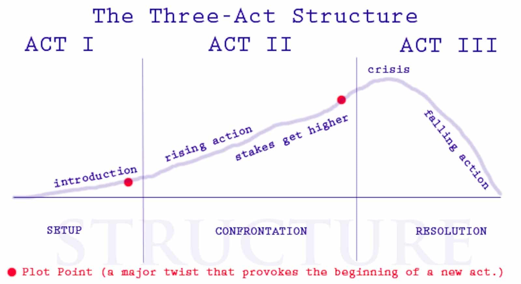

## The parts of a (data) science *story*

Now, when we map these story components back onto the more “traditional” components of a science presentation,

we gain a new understanding of why and how we should structure each section.

- Introduction: Intro
- Rising action: Methods
- Crisis: Results
- Falling action: Conclusion

## Introduction section

The goal of this section is to establish the conflict research question.

The introduction section answers the questions:

- What is your research question?
- Why should the audience care?

## Methods section

The goal of this section is to establish the rising action additional context needed to interpret the results.

A secondary goal of this section is to establish your credibility as the expert.

The methods section answers the questions:

- Where do your results come from?
- How should the audience interpret them?
- Why should the audience believe them?

## Methods section

In a data science talk for a non-expert audience, the methods section answers the questions:

- What are the data about?
- Who collected the data?
- What specific variables were measured? How?
- What does the audience need to know about the data for the results to make sense?

## Results section

The goal of this section is to explain the crisis takeaway of the data.

**The results section answers the research question.**

The results can often follow their own mini-story structure.

## Results section

[video not shown]

## Conclusion section

The goal of this section is to explain the falling action what the takeaway means for the audience.

The conclusion section answers the questions:

- What should the audience think after the talk is over?
- What should the audience do after the talk is over?

## In conclusion…

A data science talk accomplishes a *goal* with an *audience.*

The most effective way to accomplish that goal with your audience is by structuring your talk using *storytelling techniques.*

How to build a presentation - WiSTEM Computational Module